# Advanced visualization with ggplot2

Challenge 2

Author

Sam Anthony

# Instructions

**Task:** Open up the New York Times article [A Summer of Strikes](https://www.nytimes.com/interactive/2023/09/03/business/economy/strikes-union-sag-uaw.html), and scroll down to the plot titled “Union membership has fallen sharply over the past four decades (Share of the work force in a union, by industry)”.

Using `ggplot2` and other tools in R, recreate this plot. Note that you will need to create the data underlying the plot yourself. You can create this data in R with `tibble()`. You can also write the data in Excel or Google Sheets and export it as a CSV file.

**Requirements for passing:**

- Panels for “All workers”, “By Sector”, and “By Industry” are shown.
- Arrows showing the change from 1983 to 2022 are shown.
- The actual percentages in 1983 and 2022 are shown as text.
- X-axis tick marks are at 0, 25, and 50.
- Plot title says “Union membership has fallen sharply over the past four decades”.
- Plot subtitle says “Share of the work force in a union, by industry”.

**Submission:** Click the “Render” button in RStudio to knit a self-contained HTML with all images embedded. Commit and push changes to this file as well as the generated HTML. Push your changes to GitHub by midnight on Monday 2/5. (GitHub classroom automatically creates a pull request for receiving feedback.)

# Setup

```r
library(tidyverse)
Industry <- read.csv('Data/Data/Industry.csv')
RecSector <- read.csv('Data/Data/RecSector.csv')
AllWorkers <- read.csv('Data/Data/AllWorkers.csv')
```

```r
# Code for generating the data (if using the tibble() approach)
```

# Visualization

```r
# Code for recreating the visualization
AllPlot <- ggplot(data = AllWorkers)+
  geom_hline(aes(yintercept = All), color = "grey90", linetype = "dashed")+
  geom_vline(xintercept = c(25, 50), color= "grey90" )+
  geom_segment(aes(x = Union_mem_1983, y = All, xend = Union_mem_2022, yend = All), arrow = arrow(length = unit(0.08, "inches")), color = "#1C5075", lwd = 0.8) +
  geom_text(aes(label = Union_mem_1983, x = Union_mem_1983 + 1, y = All))+
  geom_text(aes(label = Union_mem_2022, x = Union_mem_2022 - 1, y = All))+
  scale_x_continuous(breaks = c(0, 25, 50), limits = c(0,50), expand = expansion(0), labels = c("0%", 25, 50))+
  theme_classic()+
  theme(axis.line.x = element_blank(), plot.title = element_text(face = "bold"))+
  labs(x = '', y = '', title = "Union membership has fallen sharply over the past four decades", subtitle = "Share of the work force in a union, by industry")
```

```r
IndustryPlot <- ggplot(data = Industry)+
  geom_hline(aes(yintercept = Industry), color = "grey90", linetype = "dashed")+
  geom_vline(xintercept = c(25, 50), color= "grey90" ) +
  geom_segment(aes(x = Union_mem_1983, y = Industry, xend = Union_mem_2022, yend = Industry), arrow = arrow(length = unit(0.08, "inches")), color = "#1C5075", lwd = 0.8) +
  geom_text(aes(x = ifelse(`Union_mem_1983`>`Union_mem_2022`, `Union_mem_1983` +1.5, `Union_mem_2022` -1.5), y=Industry, label = `Union_mem_1983`), size = 3.5)+
  geom_text(aes(x = ifelse(`Union_mem_1983`<`Union_mem_2022`, `Union_mem_1983` +1.5, `Union_mem_2022` -1.5), y=Industry,label = `Union_mem_2022`), size = 3.5)+
  # geom_text(aes(label = Union_mem_1983, x = Union_mem_1983 + 1, y = Industry)) +
  # geom_text(aes(label = Union_mem_2022, x = Union_mem_2022 - 1, y = Industry)) +
  scale_x_continuous(breaks = c(0, 25, 50), limits = c(0,50), expand = expansion(0), labels = c("0%", 25, 50)) +
  theme_classic() +
  theme(axis.line.x = element_blank(), plot.title = element_text(face = "bold")) +
  labs(x = '', y = '', title = "BY INDUSTRY")
```

```r
RecPlot <- ggplot(data = RecSector)+
  geom_hline(aes(yintercept = Sector), color = "grey90", linetype = "dashed")+
  geom_vline(xintercept = c(25, 50), color= "grey90" )+
  geom_segment(aes(x = Union_mem_1983, y = Sector, xend = Union_mem_2022, yend = Sector), arrow = arrow(length = unit(0.08, "inches")), color = "#1C5075", lwd = 0.8) +
  geom_text(aes(label = Union_mem_1983, x = Union_mem_1983 + 1, y = Sector))+
  geom_text(aes(label = Union_mem_2022, x = Union_mem_2022 - 1, y = Sector))+
  scale_x_continuous(breaks = c(0, 25, 50), limits = c(0,50), expand = expansion(0), labels = c("0%", 25, 50))+
  theme_classic()+
  theme(axis.line.x = element_blank(), plot.title = element_text(face = "bold"))+
  labs(x = '', y = '', title = "BY SECTOR")
```

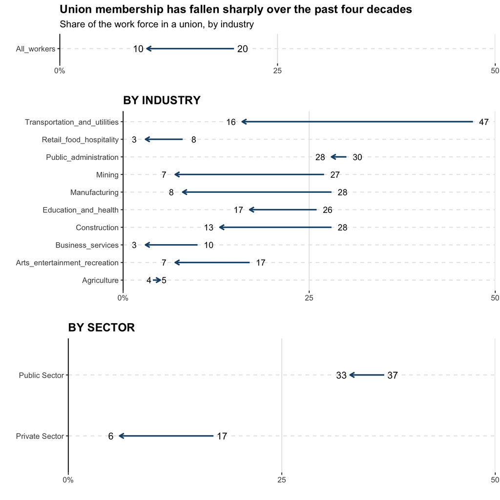

```r
figure <- ggpubr::ggarrange(AllPlot, IndustryPlot, RecPlot, ncol = 1, nrow = 3, heights = c(1, 2.5, 2))

figure
```

# AI usage

If you use an AI tool (e.g., ChatGPT, Google Bard) to help with this assignment, please paste below the prompts you use and their associated output

**Prompt:**

**Output:**

Keep in mind that the use of AI has a [huge energy cost](https://lmyint.github.io/212_spring_2024/syllabus.html#artificial-intelligence-ai-use). Please describe an energy-saving activity that you can start engaging in to offset this cost.

**Energy-saving activity:**